# Exam template - Bayesian networks - 2020

Søren Højsgaard

28/10/2020

## Introduction

This exercise is about the Bayesian networks as discussed in Mathematical Modelling. During the oral exam you will have 20 min to present the exercise. You decide what topics to cover and how to present them, however, we will ask questions to any part of the exercise and presentation. Feel free to work in small groups.

## Belief propagation

Consider the following excerpt from the chest clinic examples:

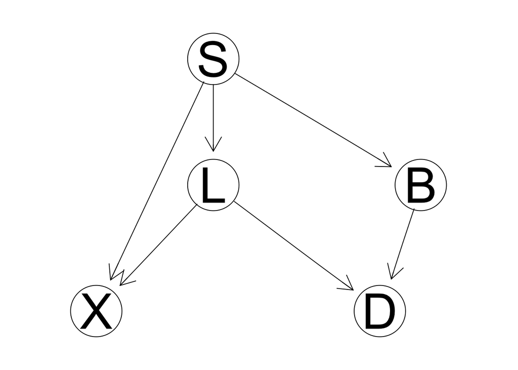

```r
library(gRbase)
dg1 <- dag(~ S + L|S + X|L:S + B|S + D|L:B)
plot(dg1)
```

The dataset

```r
data(chestSim1000, package="gRbase")
head(chestSim1000)
```

```
##   asia tub smoke lung bronc either xray dysp
## 1   no  no    no   no   yes     no   no  yes
## 2   no  no   yes   no   yes     no   no  yes
## 3   no  no   yes   no    no     no   no   no
## 4   no  no    no   no    no     no   no   no
## 5   no  no   yes   no   yes     no   no  yes
## 6   no  no   yes  yes   yes    yes  yes  yes
```

contains ``data’’ from which the conditional probability tables (CPTs) can be estimated.

1. Extract the necessary CPTs from data, and construct the Bayesian network.
2. What does information about *dysp* tell is about *smoke*, i.e. what is the conditional distribution *smoke* given *dysp*?
3. If we know *smoke*, what does additional information about *bronc* tell us about *lung*? That is, what is the conditional distribution of *lung* given *smoke*, and what is the conditional distribution of *lung* given *smoke* and *bronc*?
4. If we know *smoke* and *dysp*, what does additional information about *bronc* tell us about *lung*?
5. Sketch the message passing algorithm ofr finding clique marginals for this specific example.

## Learning networks

Consider the *cad* data in gRbase. There are two datasets: *cad1* which is complete and *cad2* which has missing values here and there.

1. Use the hill climbing algorithm function from the bnlearn package to estimate different Bayesian networks based on data *cad1*. See R script provided elsewhere.
2. Predict the value of the CAD variable in the dataset *cad1* for each of the models you find. Predict the value of the CAD variable in the dataset *cad2* for each of the models you find. Is it most appropriate to evaluate the models based on *cad1* or on *cad2*.
3. Compute the misclassification probabilities for persons with CAD and persons without CAD for each model. Which misclassification is most severe?